# SU_25_River_Rockfish_Proj_Ambient_V0.2

River Mckegney

2025-07-27

## Setup, and Packages

Code Packages:

```r
# Load packages
library(gridExtra) # For using grid.table to save tables as images
library(flextable) # Alternative method to save df as image
library(tidyverse)
library(zoo)
library(lme4)
library(lmerTest)
library(rlang)
library(nortest) # For ad.test
library(car) # For homogeneity of variance with leveneTest
library(rcompanion) # For scheirerRayHare test
library(pastecs) # For stat.desc
library(ggpubr) # For assumption plots
library(conover.test) # For the conover.Iman() test function
library(DescTools) # Contain alternative ConoverTest function
library(rstatix) # tidyverse adapted stat tests and mshapiro_test() functions
library(DHARMa) # For multi-level lm models and shapiro test
library(patchwork) # For combining ggplots
```

## Data Entry: Read-in data

```r
# Read and call data into df

# Primary samples df
ABL90 <- read.csv("Raw_Data/ABL90_Raw.csv")

# River's Parturition metadata
partuition_subcat <- read.csv("Raw_Data/River's_Rockfish_Metadata_Parturition_V7.csv")
```

## Data Filtering

```r
# Data sifting: ABL90 dataset

# Step 1: Remove missing info
ABL_set1 <- ABL90 %>%
  filter(Patient.ID_edited != "")


# Step 2: Separate Patient.ID into columns of sample types: blood plasma and instant freeze plasma
ABL_set2 <- separate(ABL_set1, 'Patient.ID_edited', into = c("Patient.ID_edited", "Sample_Type"), sep = ",")
# Step 3:
# Convert Patient.ID_edited column data to character type
ABL_set2$Patient.ID_edited <- as.character(ABL_set2$Patient.ID_edited)
```

```r
# Step 4 & 5: Sussing out specific sample errors

# Remove insufficient samples
ABL_set3 <- ABL_set2 %>%
  filter(!is.na("Type")) %>%
  filter(!str_detect(Errors.detected.during.measurement, "Insufficient sample"))

# Remove inhomogeneous samples
ABL_set3 <- ABL_set3 %>%
  filter(!is.na("Type")) %>%
  filter(!str_detect(Errors.detected.during.measurement, "Inhomogeneous sample"))

# Step 6: Filter for only blood samples
ABL_b_samp <- ABL_set3 %>%
  filter(Sample_Type == "b")
```

## Merge Datasets:

Join ABL90 df with parturition_subcat df: Making ABL_merged

```r
# Rename columns to match: Change 'ID' in parturition_subcat to 'Patient.ID_edited' so it is ready to join with ABL90 df

# Please note the 'Treatment' col in parturition_subcat does not match with the finalized 'Ambient.Or.OAH' col in metadata_atresia_guide or ABL90_merged df

# Rename 'ID' col to 'patient.ID_edited'
partuition_subcat <- partuition_subcat %>%
  rename(Patient.ID_edited = ID)
```

```r
# Connect main ABL90 dataset with my (River's) sub categorized parturition metadata
# ABL_merged <- partuition_subcat %>%
# left_join(ABL_b_samp, by = "Patient.ID_edited")

ABL_merged <- ABL_b_samp %>%
inner_join(partuition_subcat, by = "Patient.ID_edited")
```

Rename Columns Neatly:

```r
# Rename Treatment & Parturition Outcome
ABL_merged <- ABL_merged %>%
  rename(Ambient.Or.OAH = Consensus_General_Treatment,
         Pregnant.Or.Atresia = Consensus_Atresia_Or_Pregnant)
```

## Remove Samples: Mortalities, NA’s, or Missing Info, and Replicates

Remove Replicate ID’s

```r
# Cross Check all Columns: Cross validation to suss correct replicate row
check_params <- ABL_merged %>%
  select(Patient.ID_edited, Time, Sample.., Measuring.Mode, Ambient.Or.OAH, Pregnant.Or.Atresia, pH, Glu..mmol.L., Hct...., Na...mmol.L., Cl...mmol.L., K...mmol.L., Ca....mmol.L., pCO2..mmHg.) %>%
  filter(Patient.ID_edited == "9782D")
print(check_params)
```

```
##   Patient.ID_edited             Time Sample.. Measuring.Mode Ambient.Or.OAH
## 1             9782D 12/28/2023 10:04     1016         C 65uL        Ambient
## 2             9782D   1/9/2024 17:21      863         S 65uL        Ambient
##   Pregnant.Or.Atresia    pH Glu..mmol.L. Hct.... Na...mmol.L. Cl...mmol.L.
## 1    Post Parturition 7.348          0.5     9.8          184          149
## 2    Post Parturition 7.446          0.7    13.3          181          161
##   K...mmol.L. Ca....mmol.L. pCO2..mmHg.
## 1         2.8          1.32         4.2
## 2         2.9          1.31         6.8
```

```r
check_params <- ABL_merged %>%
  select(Patient.ID_edited, Time, Sample.., Measuring.Mode, Ambient.Or.OAH, Pregnant.Or.Atresia, pH, Glu..mmol.L., Hct...., Na...mmol.L., Cl...mmol.L., K...mmol.L., Ca....mmol.L., pCO2..mmHg.) %>%
  filter(Patient.ID_edited == "9783D")
print(check_params)
```

```
##   Patient.ID_edited            Time Sample.. Measuring.Mode Ambient.Or.OAH
## 1             9783D 1/19/2024 10:37      934         S 65uL        Ambient
## 2             9783D  1/7/2024 12:32      860         S 65uL        Ambient
##   Pregnant.Or.Atresia    pH Glu..mmol.L. Hct.... Na...mmol.L. Cl...mmol.L.
## 1    Post Parturition 7.484          1.7     0.2          175          193
## 2    Post Parturition 7.450          1.3    14.7          179          164
##   K...mmol.L. Ca....mmol.L. pCO2..mmHg.
## 1        34.5          1.29         8.5
## 2         2.5          1.30         5.3
```

```r
# Removed replicates: 9782D (2x) and 9783D (2x)
ABL_merged <- ABL_merged %>%
  filter(Sample.. != "863",
         Sample.. != "934")
```

Review Replicates:

| Row | ID | Time | Sample.. | Measuring.Mode | pH | Glu.mmol.L. | Hct…. | Na…mmol.L. | Cl…mmol.L. | K…mmol.L. | Ca.mmol.L. |
| --- | --- | --- | --- | --- | --- | --- | --- | --- | --- | --- | --- |
| 32 | 9782D | 12/28/2023 10:04 | 1016 | C 65uL | 7.348 | 0.5 | 9.8 | 184 | 149 | 2.8 | 1.32 |
| 39 | 9782D | 1/9/2024 17:21 | 863 | S 65uL | 7.446 | 0.7 | 13.3 | 181 | 161 | 2.9 | 1.31 |
| 36 | 9783D | 1/19/2024 10:37 | 934 | S 65uL | 7.484 | 1.7 | **0.2** | 175 | 193 | **34.5** | 1.29 |
| 41 | 9783D | 1/7/2024 12:32 | 860 | S 65uL | 7.450 | 1.3 | **14.7** | 179 | 164 | **2.5** | 1.30 |

Methods for replicate sample removal: Check processing date of IDs, and remove samples that do not match that date.

Case ID_9782D:

- Origianl ABL90 set contains:
- 9782D,b (Sample.. 1016, Time = 12/28/2023 10:04:00 AM)
- 9782D,p (Sample.. 1020, Time = 12/28/2023 10:25:00 AM)
- 9782D,p (Sample.. 865, Time = 1/9/2024 5:29:00 PM)
- 9782D,b (Sample.. 863, Time = 1/9/2024 5:21:00 PM)
- 2024_Fish_Metadata.csv says ID_9782D was processed 3/29/2024
- Note Processing date in metadata will not match time date stamp in ABL90 data due to the machine being reset, and innacurrate dates being automatically recorded.

Deciding info: - For ID-9782D, refer to metadata sheet and look for other samples with that same processing date, then view thoes samples ABL90 ‘Time’. Try to find a matching ‘Time’ with other IDs and 9782D that were processed together during the same time recorded by the machine.

Case ID_9783D

- Original ABL90 dataset contains:
- 9783D,b (Sample.. 934, Time = 1/19/2024 10:37:00 AM)
- 9783D,c (Sample.. 861, Time = 1/7/2024 12:38:00 PM)
- 9783D,b (Sample.. 860, Time = 1/7/2024 12:32:00 PM)
- 2024_Fish_Metadata.csv says ID_9783D was processed 3/20/2024
- Informed that ID_9783D: Sample.. 934 is a plasma sample (on account of its low hct value), remove this and **keep Sample.. 860 (parameter values appear correct)**.

# Samples: Data subsets

Remove Motalities and No info IDs and assign analysis ready data-frames:

```r
# New df with Moralities removed: Note none of these samples made it into ABL90 df anyway, so looks like they are already filtered out.
 Live_Samples <- ABL_merged %>%
  filter(Patient.ID_edited != "9780C", # Mortality
         Patient.ID_edited != "777AE", # Mortality
         Patient.ID_edited != "777CA") # Mortality after parturition


# New df with mortality and 'No info' Id's removed
 Primary_Samples <- Live_Samples %>%
   filter(Patient.ID_edited != "777A0", # No info
           Patient.ID_edited != "9782F", # No info
           Patient.ID_edited != "777B3", # No info
           Patient.ID_edited != "777AA", # No info
           Patient.ID_edited != "777DE", # No info
           Patient.ID_edited != "777CE", # No info
           Patient.ID_edited != "777A6") # No info


# New df of Only Ambient Treatment: For testing parturition success
 Ambient_Samples <- Primary_Samples %>%
   filter(Ambient.Or.OAH == "Ambient")

# New df of Fecundity Samples:
 Fecundity_Samples <- Primary_Samples %>%
   filter(Fecundity_Or_Brood_Count != "NA",
     Fecundity_Class != "NA") # removes 97706

# Fecundity samples without atresia Ids
 Fecundity_No_Atresia_Samples <- Primary_Samples %>%
   filter(All_Fecundity != "Na",
          All_Fecundity != 0)  # removes atresia IDs

# Fecundity Ambient Samples
 Amb_Fec_Samples <- Primary_Samples %>%
   filter(Ambient.Or.OAH == "Ambient",
          All_Fecundity != "NA") # removes OAH treatment samples and ID 97706

# Fecundity Ambient Samples without atresia Ids
 Amb_Fec_No_Atresia_Samples <- Primary_Samples %>%
   filter(Ambient.Or.OAH == "Ambient", # removes OAH treatment
          All_Fecundity != "NA", # removes all missing info IDs
          All_Fecundity != 0) # removes atresia IDs
```

Change Data Types:

```r
# Change Continuous Data to type to numeric, double, or factor

# Change data type of ions to factor or numeric
#glimpse(General_Samples)
#glimpse(Ambient_Samples)

Primary_Samples <- Primary_Samples %>%
  mutate(across(c(All_Fecundity, pH, Hct...., Glu..mmol.L., Na...mmol.L., Cl...mmol.L., K...mmol.L., Ca....mmol.L.), as.numeric))

Ambient_Samples <- Ambient_Samples %>%
  mutate(across(c(All_Fecundity, pH, Hct...., Glu..mmol.L., Na...mmol.L., Cl...mmol.L., K...mmol.L., Ca....mmol.L.), as.numeric))

Fecundity_Samples <- Fecundity_Samples %>%
  mutate(across(c(All_Fecundity, pH, Hct...., Glu..mmol.L., Na...mmol.L., Cl...mmol.L., K...mmol.L., Ca....mmol.L.), as.numeric))

Fecundity_No_Atresia_Samples <- Fecundity_Samples %>%
  mutate(across(c(All_Fecundity, pH, Hct...., Glu..mmol.L., Na...mmol.L., Cl...mmol.L., K...mmol.L., Ca....mmol.L.), as.numeric))

Amb_Fec_Samples <- Amb_Fec_Samples %>%
  mutate(across(c(All_Fecundity, pH, Hct...., Glu..mmol.L., Na...mmol.L., Cl...mmol.L., K...mmol.L., Ca....mmol.L.), as.numeric))

Amb_Fec_No_Atresia_Samples <- Amb_Fec_No_Atresia_Samples %>%
  mutate(across(c(All_Fecundity, pH, Hct...., Glu..mmol.L., Na...mmol.L., Cl...mmol.L., K...mmol.L., Ca....mmol.L.), as.numeric))

# glimpse(Primary_Samples)
# glimpse(Ambient_Samples)
# glimpse(Fecundity_Samples)
# glimpse(Amb_Fec_Samples)
```

## Order Factor Levels

```r
# Fecundity data

#unique(Fecundity_Samples$Fecundity_Class)

# Arrange the order of parturition categories for visualizations & tests

# Primary Samples

# Arrange Treatment
Primary_Samples$Ambient.Or.OAH <- ordered(Primary_Samples$Ambient.Or.OAH, levels = c("Ambient", "OAH"))

# Arrange Parturition outcome
Primary_Samples$Pregnant.Or.Atresia <- ordered(Primary_Samples$Pregnant.Or.Atresia, levels = c("Post Parturition", "Atresia"))

# Arrange Brood Condition
Primary_Samples$Consensus_Brood_Condition <- ordered(Primary_Samples$Consensus_Brood_Condition, levels = c("Excellent", "Normal", "Low", "Very Low", "Atresia"))

# Arrange Fecundity Class
Primary_Samples$Fecundity_Class <- ordered(Primary_Samples$Fecundity_Class, levels = c("High (>50,000)", "Low (~1,000s)", "Atresia"))

# Remove NAs from ordered character factors
Primary_Samples <- Primary_Samples %>%
  filter(Fecundity_Class != is.na(Fecundity_Class)) %>%
  filter(Consensus_Brood_Condition != is.na(Consensus_Brood_Condition))


# Ambient data
Ambient_Samples$Ambient.Or.OAH <- ordered(Ambient_Samples$Ambient.Or.OAH, levels = c("Ambient", "OAH"))

Ambient_Samples$Pregnant.Or.Atresia <- ordered(Ambient_Samples$Pregnant.Or.Atresia, levels = c("Post Parturition", "Atresia"))

Ambient_Samples$Consensus_Brood_Condition <- ordered(Ambient_Samples$Consensus_Brood_Condition, levels = c("Excellent", "Normal", "Low", "Atresia"))

Ambient_Samples$Fecundity_Class <- ordered(Ambient_Samples$Fecundity_Class, levels = c("High (>50,000)", "Low (~1,000s)", "Atresia"))

# Remove NAs from ordered character factors
Ambient_Samples <- Ambient_Samples %>%
  filter(Fecundity_Class != is.na(Fecundity_Class)) %>%
  filter(Consensus_Brood_Condition != is.na(Consensus_Brood_Condition))

# Ambient Fecundity data
Amb_Fec_No_Atresia_Samples$Ambient.Or.OAH <- ordered(Amb_Fec_No_Atresia_Samples$Ambient.Or.OAH, levels = c("Ambient", "OAH"))

Amb_Fec_No_Atresia_Samples$Pregnant.Or.Atresia <- ordered(Amb_Fec_No_Atresia_Samples$Pregnant.Or.Atresia, levels = c("Post Parturition", "Atresia"))

Amb_Fec_No_Atresia_Samples$Consensus_Brood_Condition <- ordered(Amb_Fec_No_Atresia_Samples$Consensus_Brood_Condition, levels = c("Excellent", "Normal", "Low", "Atresia"))

Amb_Fec_No_Atresia_Samples$Fecundity_Class <- ordered(Amb_Fec_No_Atresia_Samples$Fecundity_Class, levels = c("High (>50,000)", "Low (~1,000s)", "Atresia"))

# Remove NAs from ordered character factors
Amb_Fec_No_Atresia_Samples <- Amb_Fec_No_Atresia_Samples %>%
  filter(Fecundity_Class != is.na(Fecundity_Class)) %>%
  filter(Consensus_Brood_Condition != is.na(Consensus_Brood_Condition))
```

# Save filtered dataset into data-worked folder

```r
# Save merged dataset in a worked folder

write.csv(x = Primary_Samples, file = "Worked-Data/Primary_Samples")

write.csv(x = Ambient_Samples, file = "Worked-Data/Ambient_Samples")

write.csv(x = Fecundity_Samples, file = "Worked-Data/Fecundity_Samples")

write.csv(x = Fecundity_No_Atresia_Samples, file = "Worked-Data/Fecundity_No_Atresia_Samples")

write.csv(x = Amb_Fec_Samples, file = "Worked-Data/Amb-Fec_Samples")

write.csv(x = Amb_Fec_No_Atresia_Samples, file = "Worked-Data/Amb_Fec_No_Atresia_Samples")
```

## Sample Size: n

```r
# Sample Size

# Ambient data:
ambient_sample_size_table <- Ambient_Samples %>%
  group_by(Ambient.Or.OAH, Consensus_Brood_Condition) %>%
  summarise(n_size = n_distinct(Patient.ID_edited), .groups = "drop")
print(ambient_sample_size_table)
```

```
## # A tibble: 4 × 3
##   Ambient.Or.OAH Consensus_Brood_Condition n_size
##   <ord>          <ord>                      <int>
## 1 Ambient        Excellent                      1
## 2 Ambient        Normal                         4
## 3 Ambient        Low                            3
## 4 Ambient        Atresia                       13
```

```r
 pdf("data-images/ambient_sample_size_table.pdf")
 grid.table(ambient_sample_size_table)
 dev.off()
```

```r
 png("data-images/ambient_sample_size_table.png")
 grid.table(ambient_sample_size_table)
 dev.off()
```

```r
ambient_fecundity_class_sample_size_table <- Ambient_Samples %>%
  group_by(Ambient.Or.OAH, Fecundity_Class) %>%
  summarise(n_size = n_distinct(Patient.ID_edited), .groups = "drop")
print(ambient_fecundity_class_sample_size_table)
```

```
## # A tibble: 3 × 3
##   Ambient.Or.OAH Fecundity_Class n_size
##   <ord>          <ord>            <int>
## 1 Ambient        High (>50,000)       4
## 2 Ambient        Low (~1,000s)        4
## 3 Ambient        Atresia             13
```

```r
 pdf("data-images/ambient_fecundity_class_sample_size_table.pdf")
 grid.table(ambient_fecundity_class_sample_size_table)
 dev.off()
```

```r
 png("data-images/ambient_fecundity_class_sample_size_table.png")
 grid.table(ambient_fecundity_class_sample_size_table)
 dev.off()
```

Sample Size Barplot:

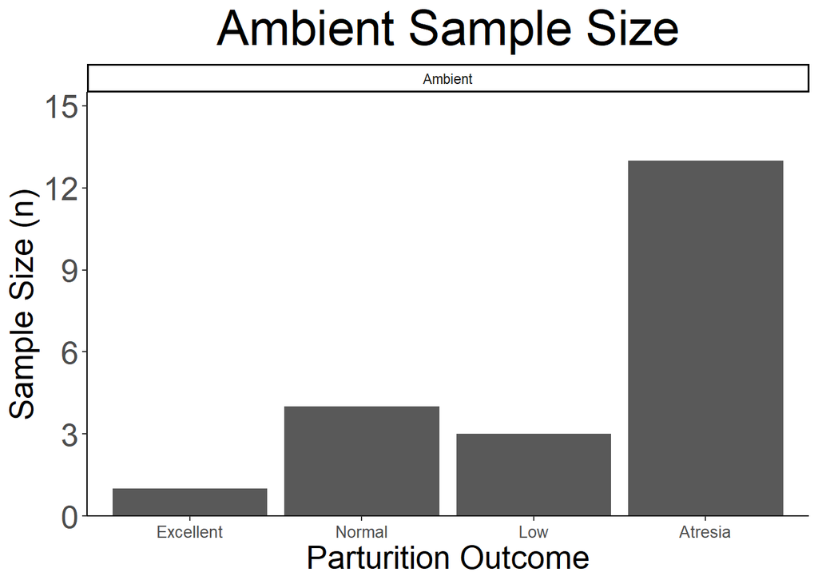

```r
# View Sample Distributions
# Sample Size barplot
# Ambient Samples

# Consensus brood condition sample barplot
ambient_sample_size_barplot <- Ambient_Samples %>%
  group_by(Consensus_Brood_Condition, Ambient.Or.OAH) %>%
  summarise(n_size = n_distinct(Patient.ID_edited), .groups = "drop") %>%
  ggplot(aes(x = Consensus_Brood_Condition, y = n_size)) +
  geom_bar(stat = "identity") +
  facet_grid(~ Ambient.Or.OAH) +
  scale_y_continuous(expand = c(0, 0), limits = c(0, 15.5), breaks = c(0, 3, 6, 9, 12, 15)) +
  labs(title = "Ambient Sample Size",
        x = "Parturition Outcome",
        y = "Sample Size (n)") +
  theme_classic() +
  theme(panel.background = element_rect(fill = "white"),
        plot.background = element_rect(fill = "white"),
        legend.background = element_rect(fill = "white", color = "black"),
        title = element_text(size = 12),
        plot.title = element_text(size = 30, hjust = 0.5),
        axis.text.x = element_text(size = 10),
        axis.text.y = element_text(size = 20),
        axis.title.x = element_text(size = 20),
        axis.title.y = element_text(size = 20))
print(ambient_sample_size_barplot)
```

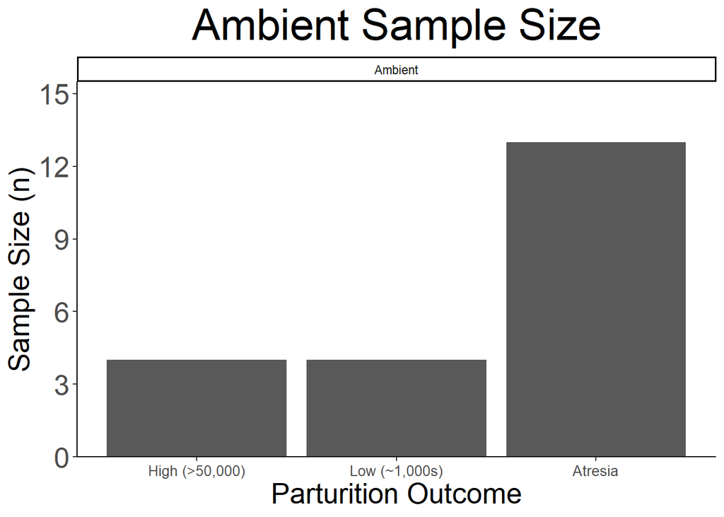

```r
ggsave(filename = "data-images/.png", plot = ambient_sample_size_barplot, device = "png")
ggsave(filename = "data-images/ambient_sample_size_barplot.pdf", plot = ambient_sample_size_barplot, device = "pdf")
# Fecundity class sample barplot
ambient_sample_size_barplot2 <- Ambient_Samples %>%
  group_by(Fecundity_Class, Ambient.Or.OAH) %>%
  summarise(n_size = n_distinct(Patient.ID_edited), .groups = "drop") %>%
  ggplot(aes(x = Fecundity_Class, y = n_size)) +
  geom_bar(stat = "identity") +
  facet_grid(~ Ambient.Or.OAH) +
  scale_y_continuous(expand = c(0, 0), limits = c(0, 15.5), breaks = c(0, 3, 6, 9, 12, 15)) +
  labs(title = "Ambient Sample Size",
        x = "Parturition Outcome",
        y = "Sample Size (n)") +
  theme_classic() +
  theme(panel.background = element_rect(fill = "white"),
        plot.background = element_rect(fill = "white"),
        legend.background = element_rect(fill = "white", color = "black"),
        title = element_text(size = 12),
        plot.title = element_text(size = 30, hjust = 0.5),
        axis.text.x = element_text(size = 10),
        axis.text.y = element_text(size = 20),
        axis.title.x = element_text(size = 20),
        axis.title.y = element_text(size = 20))
print(ambient_sample_size_barplot2)
```

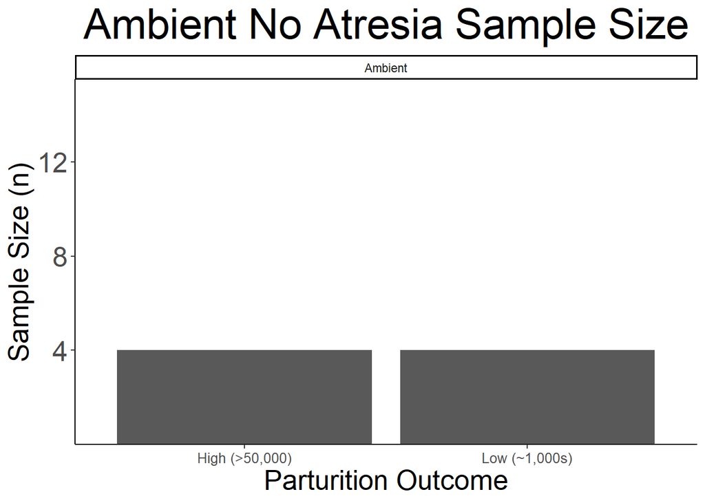

```r
ggsave(filename = "data-images/.png", plot = ambient_sample_size_barplot2, device = "png")
ggsave(filename = "data-images/ambient_sample_size_barplot2.pdf", plot = ambient_sample_size_barplot2, device = "pdf")
# Amb Fec No atresia sample size

amb_fec_no_atresia_barplot <- Amb_Fec_No_Atresia_Samples %>%
  group_by(Fecundity_Class, Ambient.Or.OAH) %>%
  summarise(n_size = n_distinct(Patient.ID_edited), .groups = "drop") %>%
  ggplot(aes(x = Fecundity_Class, y = n_size)) +
  geom_bar(stat = "identity") +
  facet_grid(~ Ambient.Or.OAH) +
  scale_y_continuous(expand = c(0, 0), limits = c(0, 15.5), breaks = c(4, 8, 12)) +
  labs(title = "Ambient No Atresia Sample Size",
        x = "Parturition Outcome",
        y = "Sample Size (n)") +
  theme_classic() +
  theme(panel.background = element_rect(fill = "white"),
        plot.background = element_rect(fill = "white"),
        legend.background = element_rect(fill = "white", color = "black"),
        title = element_text(size = 12),
        plot.title = element_text(size = 30, hjust = 0.5),
        axis.text.x = element_text(size = 10),
        axis.text.y = element_text(size = 20),
        axis.title.x = element_text(size = 20),
        axis.title.y = element_text(size = 20))
print(amb_fec_no_atresia_barplot)
```

```r
ggsave(filename = "data-images/.png", plot = amb_fec_no_atresia_barplot, device = "png")
ggsave(filename = "data-images/amb_fec_no_atresia_barplot.pdf", plot = amb_fec_no_atresia_barplot, device = "pdf")
```

## Paramater Analysis:

# pH

pH Summary Stats

```r
# pH
# Summary stats

# Ambient data
Ambient_Samples %>%
  group_by(Ambient.Or.OAH, Consensus_Brood_Condition) %>%
  summarize(count = n(),
            median = round(median(pH), 3),
            mean = round(mean(pH), 3),
            sd = round(sd(pH), 3),
            cv = round(sd(pH)/mean(pH), 3)) %>%
  ungroup()
```

```
## # A tibble: 4 × 7
##   Ambient.Or.OAH Consensus_Brood_Condition count median  mean     sd     cv
##   <ord>          <ord>                     <int>  <dbl> <dbl>  <dbl>  <dbl>
## 1 Ambient        Excellent                     1   7.43  7.43 NA     NA
## 2 Ambient        Normal                        4   7.48  7.45  0.087  0.012
## 3 Ambient        Low                           3   7.43  7.44  0.046  0.006
## 4 Ambient        Atresia                      13   7.37  7.38  0.1    0.014
```

```r
Ambient_Samples %>%
  group_by(Ambient.Or.OAH, Fecundity_Class) %>%
  summarize(count = n(),
            median = round(median(pH), 3),
            mean = round(mean(pH), 3),
            sd = round(sd(pH), 3),
            cv = round(sd(pH)/mean(pH), 3)) %>%
  ungroup()
```

```
## # A tibble: 3 × 7
##   Ambient.Or.OAH Fecundity_Class count median  mean    sd    cv
##   <ord>          <ord>           <int>  <dbl> <dbl> <dbl> <dbl>
## 1 Ambient        High (>50,000)      4   7.44  7.43 0.076 0.01
## 2 Ambient        Low (~1,000s)       4   7.46  7.45 0.054 0.007
## 3 Ambient        Atresia            13   7.37  7.38 0.1   0.014
```

```r
Amb_Fec_No_Atresia_Samples %>%
  group_by(Ambient.Or.OAH, Fecundity_Class) %>%
  summarize(count = n(),
            median = round(median(pH), 3),
            mean = round(mean(pH), 3),
            sd = round(sd(pH), 3),
            cv = round(sd(pH)/mean(pH), 3)) %>%
  ungroup()
```

```
## # A tibble: 2 × 7
##   Ambient.Or.OAH Fecundity_Class count median  mean    sd    cv
##   <ord>          <ord>           <int>  <dbl> <dbl> <dbl> <dbl>
## 1 Ambient        High (>50,000)      4   7.44  7.43 0.076 0.01
## 2 Ambient        Low (~1,000s)       4   7.46  7.45 0.054 0.007
```

pH Boxplot

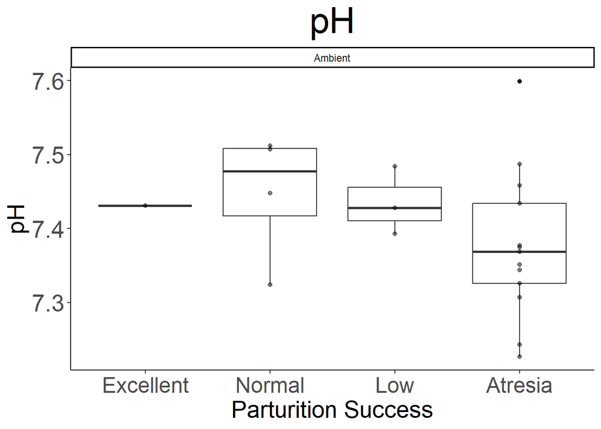

```r
# pH boxplot

# Ambient Samples
pH_ambient_boxplot <- ggplot(data = Ambient_Samples) +
  geom_boxplot(aes(x = Consensus_Brood_Condition, y = pH)) +
  geom_point(aes(x = Consensus_Brood_Condition, y = pH), alpha = 0.5, colour = "black") +
  labs(title = "pH", x = "Parturition Success", y = "pH") +
  facet_wrap(~ Ambient.Or.OAH) +
  theme_classic() +
  theme(panel.background = element_rect(fill = "white"),
        plot.background = element_rect(fill = "white"),
        legend.background = element_rect(fill = "white", color = "black"),
        title = element_text(size = 12),
        plot.title = element_text(size = 30, hjust = 0.5),
        axis.text.x = element_text(size = 18),
        axis.text.y = element_text(size = 20),
        axis.title.x = element_text(size = 20),
        axis.title.y = element_text(size = 20))

print(pH_ambient_boxplot)
```

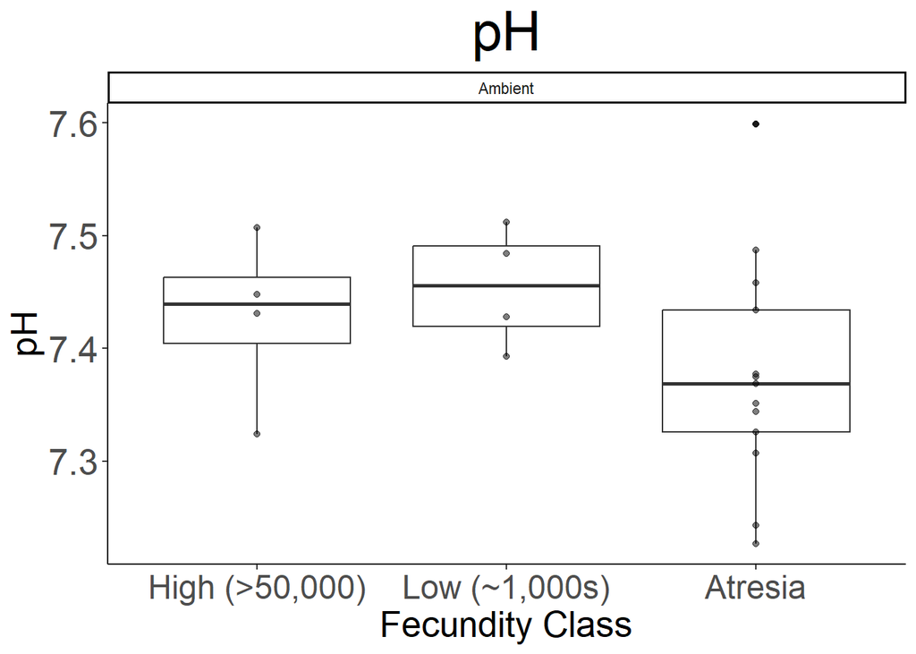

```r
ggsave(filename = "data-images/pH_ambient_boxplot.pdf", plot = pH_ambient_boxplot, device = "pdf")
ggsave(filename = "data-images/pH_ambient_boxplot.png", plot = pH_ambient_boxplot, device = "png")
pH_ambient_fecundity_boxplot <- ggplot(data = Ambient_Samples) +
  geom_boxplot(aes(x = Fecundity_Class, y = pH)) +
  geom_point(aes(x = Fecundity_Class, y = pH), alpha = 0.5, colour = "black") +
  labs(title = "pH", x = "Fecundity Class", y = "pH") +
  facet_wrap(~ Ambient.Or.OAH) +
  theme_classic() +
  theme(panel.background = element_rect(fill = "white"),
        plot.background = element_rect(fill = "white"),
        legend.background = element_rect(fill = "white", color = "black"),
        title = element_text(size = 12),
        plot.title = element_text(size = 30, hjust = 0.5),
        axis.text.x = element_text(size = 18),
        axis.text.y = element_text(size = 20),
        axis.title.x = element_text(size = 20),
        axis.title.y = element_text(size = 20))

print(pH_ambient_fecundity_boxplot)
```

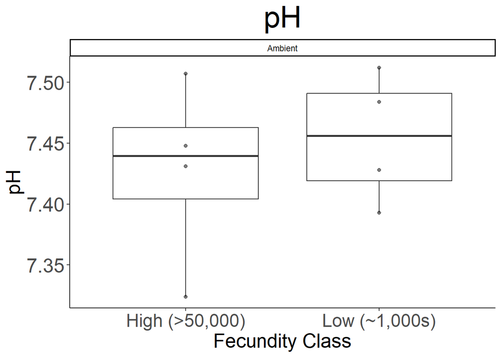

```r
ggsave(filename = "data-images/pH_ambient_fecundity_boxplot.pdf", plot = pH_ambient_fecundity_boxplot, device = "pdf")
ggsave(filename = "data-images/pH_ambient_fecundity_boxplot.png", plot = pH_ambient_fecundity_boxplot, device = "png")
pH_amb_fec_no_atresia_boxplot <- ggplot(data = Amb_Fec_No_Atresia_Samples) +
  geom_boxplot(aes(x = Fecundity_Class, y = pH)) +
  geom_point(aes(x = Fecundity_Class, y = pH), alpha = 0.5, colour = "black") +
  labs(title = "pH", x = "Fecundity Class", y = "pH") +
  facet_wrap(~ Ambient.Or.OAH) +
  theme_classic() +
  theme(panel.background = element_rect(fill = "white"),
        plot.background = element_rect(fill = "white"),
        legend.background = element_rect(fill = "white", color = "black"),
        title = element_text(size = 12),
        plot.title = element_text(size = 30, hjust = 0.5),
        axis.text.x = element_text(size = 18),
        axis.text.y = element_text(size = 20),
        axis.title.x = element_text(size = 20),
        axis.title.y = element_text(size = 20))

print(pH_amb_fec_no_atresia_boxplot)
```

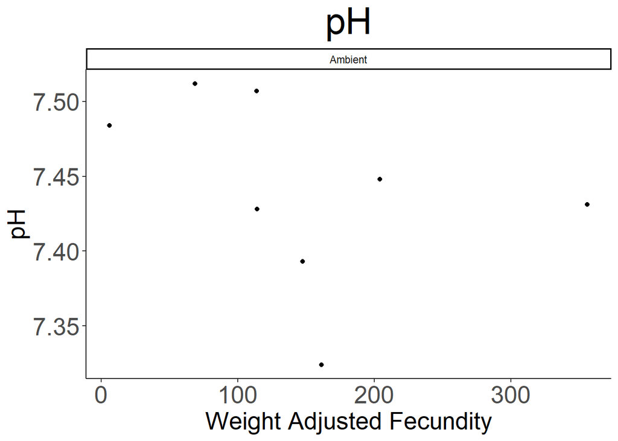

```r
ggsave(filename = "data-images/pH_amb_fec_no_atresia_boxplot.pdf", plot = pH_amb_fec_no_atresia_boxplot, device = "pdf")
ggsave(filename = "data-images/pH_amb_fec_no_atresia_boxplot.png", plot = pH_amb_fec_no_atresia_boxplot, device = "png")
pH_amb_fec_no_atresia_scatterplot <- Amb_Fec_No_Atresia_Samples %>%
  ggplot() +
  geom_point(aes(x = Weight_Adjusted_Fecundity_Fecundity.Mean_Weight, y = pH), colour = "black") +
  labs(title = "pH", x = "Weight Adjusted Fecundity", y = "pH") +
  facet_wrap(~ Ambient.Or.OAH) +
  theme_classic() +
  theme(panel.background = element_rect(fill = "white"),
        plot.background = element_rect(fill = "white"),
        legend.background = element_rect(fill = "white", color = "black"),
        title = element_text(size = 12),
        plot.title = element_text(size = 30, hjust = 0.5),
        axis.text.x = element_text(size = 20),
        axis.text.y = element_text(size = 20),
        axis.title.x = element_text(size = 20),
        axis.title.y = element_text(size = 20))

print(pH_amb_fec_no_atresia_scatterplot)
```

```r
ggsave(filename = "data-images/pH_amb_fec_no_atresia_scatterplot.pdf", plot = pH_amb_fec_no_atresia_scatterplot, device = "pdf")
ggsave(filename = "data-images/pH_amb_fec_no_atresia_scatterplot.png", plot = pH_amb_fec_no_atresia_scatterplot, device = "png")
```

# pH Stat Tests

Differences: Between Brood Conditon

```r
# pH
# Ambient ANOVA Test

# Testing for differences in ambient parturition success metrics
# One-way ANOVA (parametric) or Kruskal-Wallis test (nonparametric)

pH_aov_ambient_brood <- aov(pH ~ Consensus_Brood_Condition, data = Ambient_Samples)
summary(pH_aov_ambient_brood)
```

```
##                           Df  Sum Sq  Mean Sq F value Pr(>F)
## Consensus_Brood_Condition  3 0.02079 0.006930   0.795  0.513
## Residuals                 17 0.14815 0.008715
```

```r
# If significant, Post Hoc Test:
# - Tukey's HSD (parametric, normality & equal variance across groups)
# - Dunn's test (non-parametric, after Kruskal-Wallis test)

TukeyHSD(pH_aov_ambient_brood)
```

```
##   Tukey multiple comparisons of means
##     95% family-wise confidence level
##
## Fit: aov(formula = pH ~ Consensus_Brood_Condition, data = Ambient_Samples)
##
## $Consensus_Brood_Condition
##                          diff        lwr        upr     p adj
## Normal-Excellent   0.01675000 -0.2799312 0.31343123 0.9984685
## Low-Excellent      0.00400000 -0.3024111 0.31041106 0.9999809
## Atresia-Excellent -0.05430769 -0.3296845 0.22106915 0.9423449
## Low-Normal        -0.01275000 -0.2154219 0.18992187 0.9978869
## Atresia-Normal    -0.07105769 -0.2227829 0.08066756 0.5566650
## Atresia-Low       -0.05830769 -0.2282740 0.11165858 0.7651322
```

```r
# Parametric tests

# Normality
shapiro.test(Ambient_Samples$pH)
```

```
##
##  Shapiro-Wilk normality test
##
## data:  Ambient_Samples$pH
## W = 0.98534, p-value = 0.9808
```

```r
shapiro.test(residuals(aov(pH ~ Consensus_Brood_Condition, data = Ambient_Samples)))
```

```
##
##  Shapiro-Wilk normality test
##
## data:  residuals(aov(pH ~ Consensus_Brood_Condition, data = Ambient_Samples))
## W = 0.95636, p-value = 0.446
```

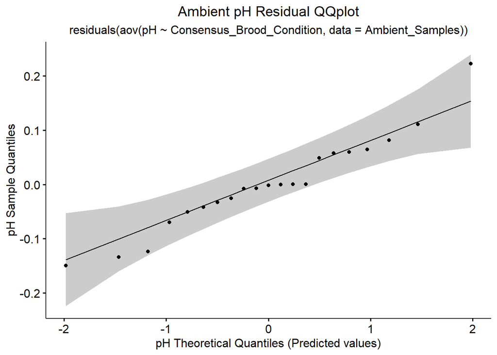

```r
# QQplot:
pH_ambient_res_qqplot <- ggqqplot(residuals(aov(pH ~ Consensus_Brood_Condition, data = Ambient_Samples))) +
labs(title = "Ambient pH Residual QQplot",
     subtitle = "residuals(aov(pH ~ Consensus_Brood_Condition, data = Ambient_Samples))",
                               x = "pH Theoretical Quantiles (Predicted values)",
                               y = "pH Sample Quantiles") +
  theme(plot.title = element_text(hjust = 0.5),
        plot.subtitle = element_text(hjust = 0.5))
print(pH_ambient_res_qqplot)
```

```r
# Parametric Variance test (Bartlett's test): require at least 2 obs for each group
#bartlett.test(pH ~ Consensus_Brood_Condition, data = Ambient_Samples)

# Nonparametric variance test (Levene's test):
leveneTest(pH ~ Consensus_Brood_Condition, data = Ambient_Samples)
```

```
## Levene's Test for Homogeneity of Variance (center = median)
##       Df F value Pr(>F)
## group  3   0.671 0.5815
##       17
```

```r
# Nonparametric stat test: Kruskall Wallis
kruskal.test(pH ~ Consensus_Brood_Condition, data = Ambient_Samples)
```

```
##
##  Kruskal-Wallis rank sum test
##
## data:  pH by Consensus_Brood_Condition
## Kruskal-Wallis chi-squared = 2.8578, df = 3, p-value = 0.4141
```

```r
# Nonparametric Post Hoc: Dunn's Test
DunnettTest(pH ~ Consensus_Brood_Condition, data = Ambient_Samples)
```

```
##
##   Dunnett's test for comparing several treatments with a control :
##     95% family-wise confidence level
##
## $Excellent
##                          diff     lwr.ci    upr.ci   pval
## Normal-Excellent   0.01675000 -0.2376275 0.2711275 0.9925
## Low-Excellent      0.00400000 -0.2587200 0.2667200 0.9999
## Atresia-Excellent -0.05430769 -0.2904186 0.1818032 0.8155
##
## ---
## Signif. codes:  0 '***' 0.001 '**' 0.01 '*' 0.05 '.' 0.1 ' ' 1
```

pH Ambient Results

Which brood condition significantly different (if any)?

Differences: Between Fecundity Class

```r
# pH
# Ambient ANOVA Test

# Testing for differences in ambient parturition success metrics
# One-way ANOVA (parametric) or Kruskal-Wallis test (nonparametric)

pH_aov_ambient_fec <- aov(pH ~ Fecundity_Class, data = Ambient_Samples)
summary(pH_aov_ambient_fec)
```

```
##                 Df  Sum Sq  Mean Sq F value Pr(>F)
## Fecundity_Class  2 0.02183 0.010916   1.336  0.288
## Residuals       18 0.14711 0.008173
```

```r
# If significant, Post Hoc Test:
# - Tukey's HSD (parametric, normality & equal variance across groups)
# - Dunn's test (non-parametric, after Kruskal-Wallis test)

TukeyHSD(pH_aov_ambient_fec)
```

```
##   Tukey multiple comparisons of means
##     95% family-wise confidence level
##
## Fit: aov(formula = pH ~ Fecundity_Class, data = Ambient_Samples)
##
## $Fecundity_Class
##                                     diff        lwr        upr     p adj
## Low (~1,000s)-High (>50,000)  0.02675000 -0.1363959 0.18989587 0.9084726
## Atresia-High (>50,000)       -0.05080769 -0.1827287 0.08111329 0.5966404
## Atresia-Low (~1,000s)        -0.07755769 -0.2094787 0.05436329 0.3141611
```

```r
# Parametric tests

# Normality
shapiro.test(Ambient_Samples$pH)
```

```
##
##  Shapiro-Wilk normality test
##
## data:  Ambient_Samples$pH
## W = 0.98534, p-value = 0.9808
```

```r
shapiro.test(residuals(aov(Cl...mmol.L. ~ Fecundity_Class, data = Ambient_Samples)))
```

```
##
##  Shapiro-Wilk normality test
##
## data:  residuals(aov(Cl...mmol.L. ~ Fecundity_Class, data = Ambient_Samples))
## W = 0.96555, p-value = 0.6339
```

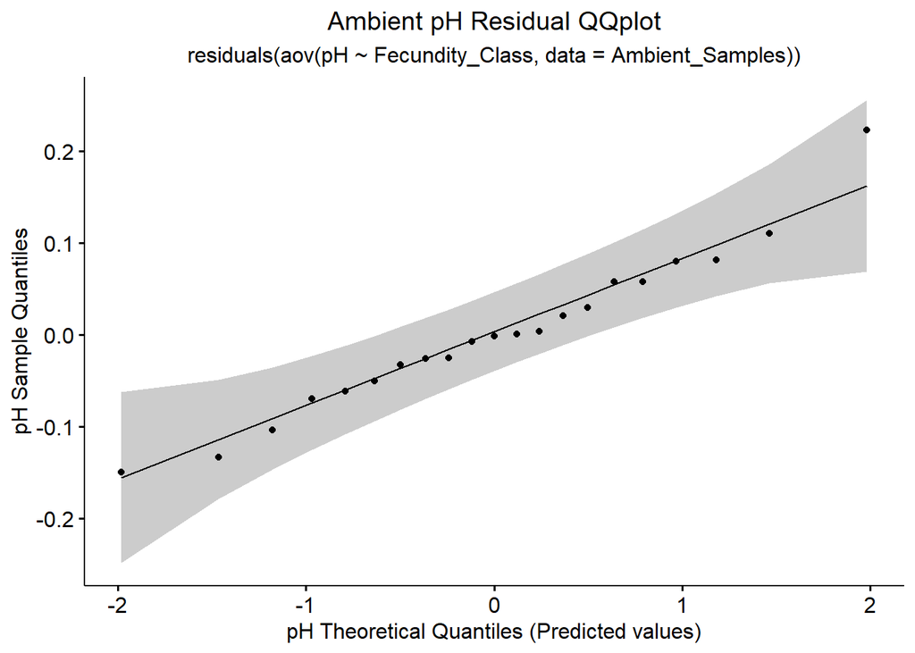

```r
# QQplot:
pH_ambient_fec_res_qqplot <- ggqqplot(residuals(aov(pH ~ Fecundity_Class, data = Ambient_Samples))) +
labs(title = "Ambient pH Residual QQplot",
     subtitle = "residuals(aov(pH ~ Fecundity_Class, data = Ambient_Samples))",
                               x = "pH Theoretical Quantiles (Predicted values)",
                               y = "pH Sample Quantiles") +
  theme(plot.title = element_text(hjust = 0.5),
        plot.subtitle = element_text(hjust = 0.5))
print(pH_ambient_fec_res_qqplot)
```

```r
# Parametric Variance test (Bartlett's test): require at least 2 obs for each group
bartlett.test(pH ~ Fecundity_Class, data = Ambient_Samples)
```

```
##
##  Bartlett test of homogeneity of variances
##
## data:  pH by Fecundity_Class
## Bartlett's K-squared = 1.4521, df = 2, p-value = 0.4838
```

```r
# Nonparametric variance test (Levene's test):
leveneTest(pH ~ Fecundity_Class, data = Ambient_Samples)
```

```
## Levene's Test for Homogeneity of Variance (center = median)
##       Df F value Pr(>F)
## group  2    0.44 0.6508
##       18
```

```r
# Nonparametric stat test: Kruskall Wallis
kruskal.test(pH ~ Fecundity_Class, data = Ambient_Samples)
```

```
##
##  Kruskal-Wallis rank sum test
##
## data:  pH by Fecundity_Class
## Kruskal-Wallis chi-squared = 3.0375, df = 2, p-value = 0.219
```

```r
# Nonparametric Post Hoc: Dunn's test
DunnettTest(pH ~ Fecundity_Class, data = Ambient_Samples)
```

```
##
##   Dunnett's test for comparing several treatments with a control :
##     95% family-wise confidence level
##
## $`High (>50,000)`
##                                     diff     lwr.ci     upr.ci   pval
## Low (~1,000s)-High (>50,000)  0.02675000 -0.1252448 0.17874478 0.8717
## Atresia-High (>50,000)       -0.05080769 -0.1737118 0.07209643 0.5071
##
## ---
## Signif. codes:  0 '***' 0.001 '**' 0.01 '*' 0.05 '.' 0.1 ' ' 1
```

pH Ambient Results

Which fecundity class significantly different (if any)?

Parametric assumptions: - Normality (Shapiro-Wilk test): **Met** - Variance (Bartlett’s test): **Met**

Correlations: Parameter to Numerical Fecundity (without Atresia IDs)

```r
# Ph
# Linear Model
pH_amb_fec_no_atresia_lm <- lm(pH ~ Weight_Adjusted_Fecundity_Fecundity.Mean_Weight, data = Fecundity_No_Atresia_Samples)
summary(pH_amb_fec_no_atresia_lm)
```

```
##
## Call:
## lm(formula = pH ~ Weight_Adjusted_Fecundity_Fecundity.Mean_Weight,
##     data = Fecundity_No_Atresia_Samples)
##
## Residuals:
##      Min       1Q   Median       3Q      Max
## -0.11940 -0.02163  0.01153  0.04429  0.05591
##
## Coefficients:
##                                                   Estimate Std. Error t value
## (Intercept)                                      7.4752402  0.0369759  202.16
## Weight_Adjusted_Fecundity_Fecundity.Mean_Weight -0.0001977  0.0001939   -1.02
##                                                 Pr(>|t|)
## (Intercept)                                     4.01e-16 ***
## Weight_Adjusted_Fecundity_Fecundity.Mean_Weight    0.338
## ---
## Signif. codes:  0 '***' 0.001 '**' 0.01 '*' 0.05 '.' 0.1 ' ' 1
##
## Residual standard error: 0.05852 on 8 degrees of freedom
##   (18 observations deleted due to missingness)
## Multiple R-squared:  0.115,  Adjusted R-squared:  0.004385
## F-statistic:  1.04 on 1 and 8 DF,  p-value: 0.3377
```

```
## qu = 0.25, log(sigma) = -4.135132 : outer Newton did not converge fully.
```

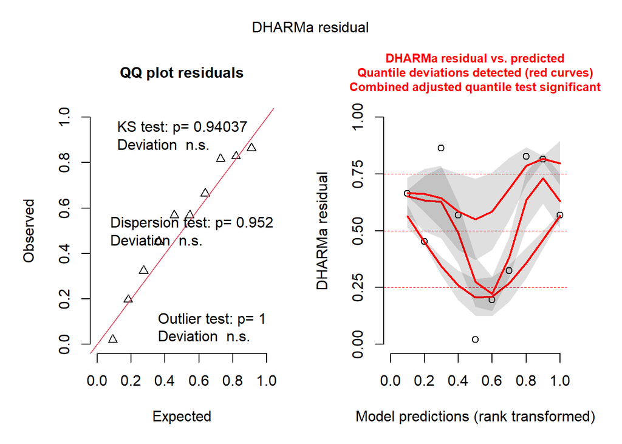

```r
pH_ambient_sim <- simulateResiduals(fittedModel = pH_amb_fec_no_atresia_lm)
plot(pH_ambient_sim)
```

```
## qu = 0.25, log(sigma) = -4.135132 : outer Newton did not converge fully.
```

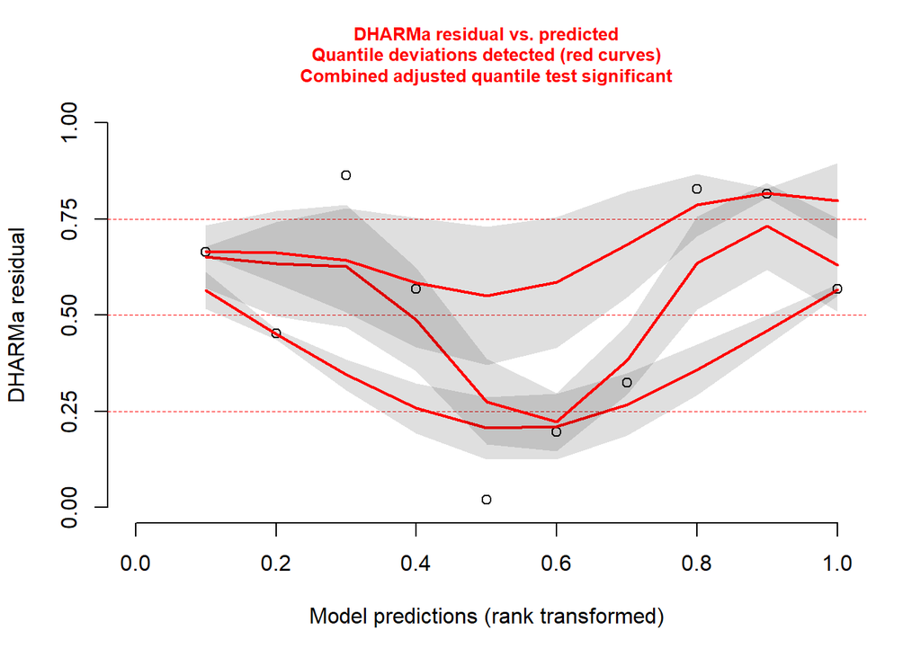

```r
plotResiduals(pH_amb_fec_no_atresia_lm)
```

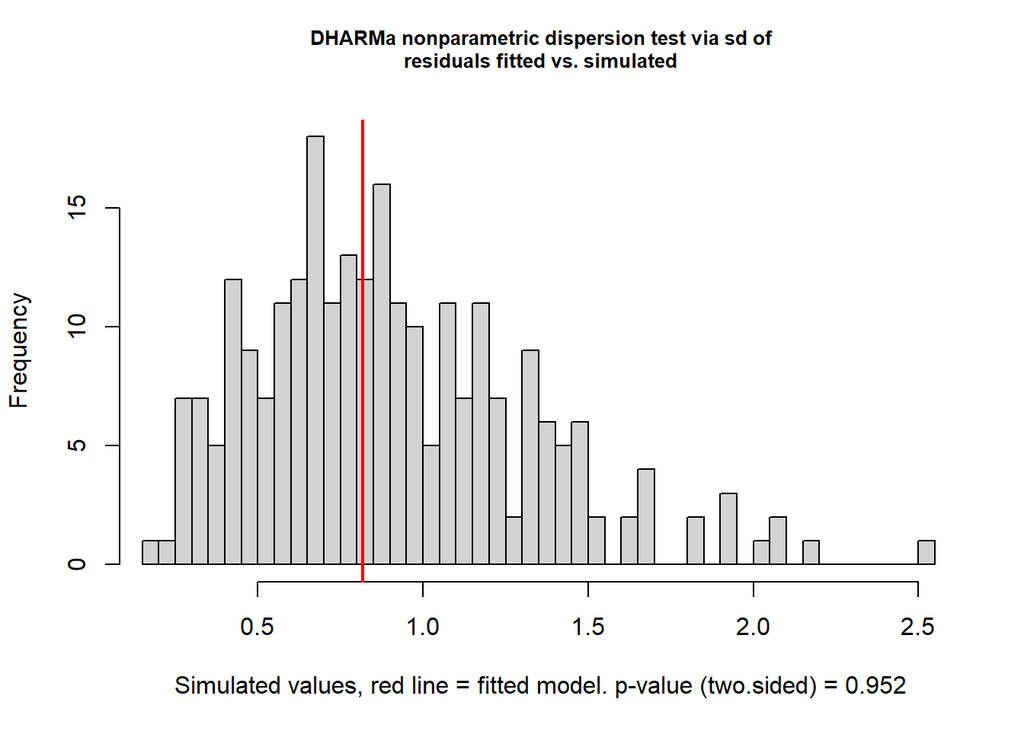

```
##
##  DHARMa nonparametric dispersion test via sd of residuals fitted vs.
##  simulated
##
## data:  simulationOutput
## dispersion = 0.90609, p-value = 0.952
## alternative hypothesis: two.sided
```

```r
testDispersion(pH_amb_fec_no_atresia_lm)
```

```r
# Normality test
shapiro.test(residuals(pH_amb_fec_no_atresia_lm))
```

```
##
##  Shapiro-Wilk normality test
##
## data:  residuals(pH_amb_fec_no_atresia_lm)
## W = 0.89785, p-value = 0.2075
```

```r
# Transform data: square root (undo log scale?)
pH_ambient_sqrt <- Amb_Fec_No_Atresia_Samples %>%
  mutate(pH = sqrt(pH))

# Rerun lm model with square root transformed data
pH_amb_fec_no_atresia_lm_sqrt <- lm(pH ~ Weight_Adjusted_Fecundity_Fecundity.Mean_Weight, data = pH_ambient_sqrt)
summary(pH_amb_fec_no_atresia_lm_sqrt)
```

```
##
## Call:
## lm(formula = pH ~ Weight_Adjusted_Fecundity_Fecundity.Mean_Weight,
##     data = pH_ambient_sqrt)
##
## Residuals:
##       Min        1Q    Median        3Q       Max
## -0.020889 -0.004920  0.002934  0.007526  0.010787
##
## Coefficients:
##                                                   Estimate Std. Error t value
## (Intercept)                                      2.734e+00  7.412e-03 368.821
## Weight_Adjusted_Fecundity_Fecundity.Mean_Weight -4.078e-05  4.222e-05  -0.966
##                                                 Pr(>|t|)
## (Intercept)                                     2.68e-14 ***
## Weight_Adjusted_Fecundity_Fecundity.Mean_Weight    0.371
## ---
## Signif. codes:  0 '***' 0.001 '**' 0.01 '*' 0.05 '.' 0.1 ' ' 1
##
## Residual standard error: 0.01157 on 6 degrees of freedom
## Multiple R-squared:  0.1346, Adjusted R-squared:  -0.009642
## F-statistic: 0.9331 on 1 and 6 DF,  p-value: 0.3714
```

```
## qu = 0.25, log(sigma) = -2.642951 : outer Newton did not converge fully.
```

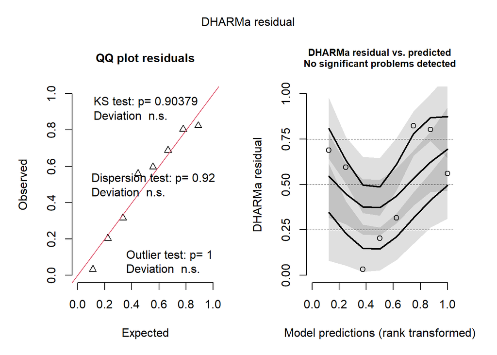

```r
pH_amb_fec_sqrt_sim <- simulateResiduals(fittedModel = pH_amb_fec_no_atresia_lm_sqrt)
plot(pH_amb_fec_sqrt_sim)
```

```
## qu = 0.25, log(sigma) = -2.642951 : outer Newton did not converge fully.
```

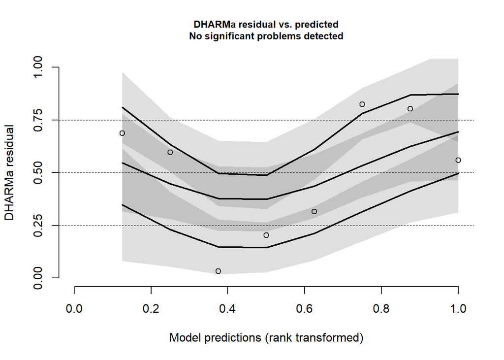

```r
plotResiduals(pH_amb_fec_no_atresia_lm_sqrt)
```

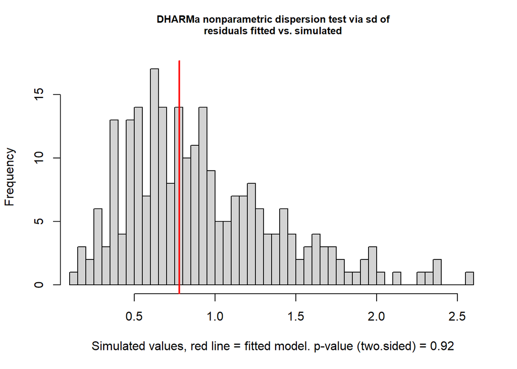

```
##
##  DHARMa nonparametric dispersion test via sd of residuals fitted vs.
##  simulated
##
## data:  simulationOutput
## dispersion = 0.84221, p-value = 0.92
## alternative hypothesis: two.sided
```

```r
testDispersion(pH_amb_fec_no_atresia_lm_sqrt)
```

```r
# Residuals of model for shapiro test
pH_amb_fec_no_atresia_lm_res <- residuals(pH_amb_fec_no_atresia_lm_sqrt)

# Normality test
shapiro.test(pH_amb_fec_no_atresia_lm_res) # normal
```

```
##
##  Shapiro-Wilk normality test
##
## data:  pH_amb_fec_no_atresia_lm_res
## W = 0.90414, p-value = 0.3147
```

```r
# Parametric variance test: bartlett's test
# Require at least 2 obs for each group
#bartlett.test(pH ~ Weight_Adjusted_Fecundity_Fecundity.Mean_Weight, data = Fecundity_No_Atresia_Samples)

# Nonparametric variance test (Levene's test)
# NA for quantitative explanatory variables
# leveneTest(pH ~ Weight_Adjusted_Fecundity_Fecundity.Mean_Weight, data = Fecundity_No_Atresia_Samples)
```

Residuals Plot (if significant)

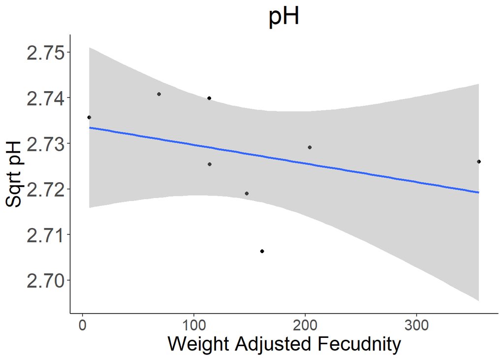

```r
# pH
# Ambient samples

# ggplot with geom_smooth(aes(x=,y=)), method = "lm")

pH_ambient_lm_scatterplot <- ggplot(data = pH_ambient_sqrt, aes(x = Weight_Adjusted_Fecundity_Fecundity.Mean_Weight, y = pH)) +
  geom_point() +
  geom_smooth(aes(group = 1), method = "lm") +
  labs(title = "pH", x = "Weight Adjusted Fecudnity", y = "Sqrt pH", color = "Category") +
  scale_y_continuous() +
  theme_classic() +
  theme(panel.background = element_rect(fill = "white"),
        plot.background = element_rect(fill = "white"),
        legend.background = element_rect(fill = "white", color = "black"),
        plot.title = element_text(size = 25, hjust = 0.5),
        axis.text.x = element_text(size = 15),
        axis.text.y = element_text(size = 20),
        axis.title.x = element_text(size = 20),
        axis.title.y = element_text(size = 20))

print(pH_ambient_lm_scatterplot)
```

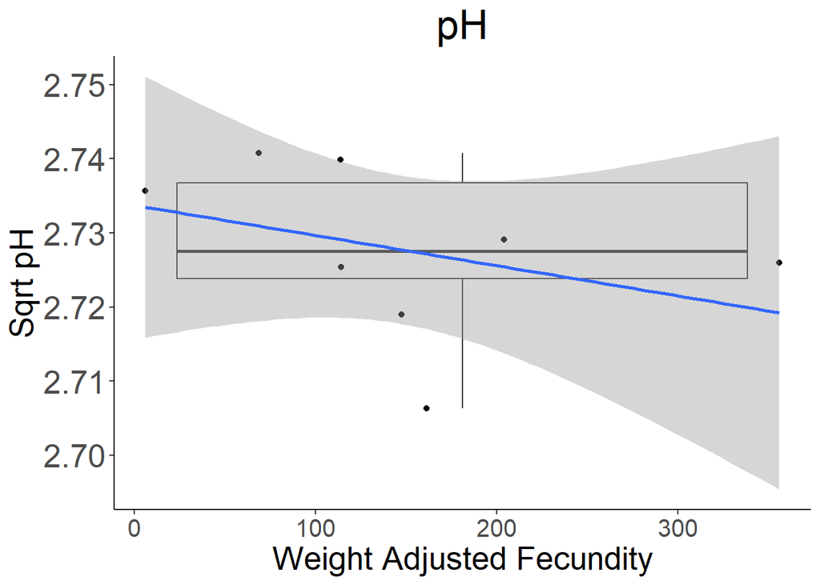

```r
ggsave(filename = "data-images/pH_ambient_lm_scatterplot.pdf", plot = pH_ambient_lm_scatterplot, device = "pdf")
ggsave(filename = "data-images/pH_ambient_lm_scatterplot.png", plot = pH_ambient_lm_scatterplot, device = "png")
# sodium
# lm Boxplot

pH_ambient_lm_boxplot <- ggplot(data = pH_ambient_sqrt, aes(x = Weight_Adjusted_Fecundity_Fecundity.Mean_Weight, y = pH)) +
  geom_boxplot() +
  geom_point() +
  geom_smooth(aes(group = 1), method = "lm") +
  labs(title = "pH", x = "Weight Adjusted Fecundity", y = "Sqrt pH", color = "Category") +
  scale_y_continuous() +
  theme_classic() +
  theme(panel.background = element_rect(fill = "white"),
        plot.background = element_rect(fill = "white"),
        legend.background = element_rect(fill = "white", color = "black"),
        plot.title = element_text(size = 25, hjust = 0.5),
        axis.text.x = element_text(size = 15),
        axis.text.y = element_text(size = 20),
        axis.title.x = element_text(size = 20),
        axis.title.y = element_text(size = 20))
print(pH_ambient_lm_boxplot)
```

# Hct : Hematocrit

hct Summary Stats

```r
# hct
# Summary stats

# Ambient data
Ambient_Samples %>%
  group_by(Ambient.Or.OAH, Consensus_Brood_Condition) %>%
  summarize(count = n(),
            median = round(median(Hct....), 3),
            mean = round(mean(Hct....), 3),
            sd = round(sd(Hct....), 3),
            cv = round(sd(Hct....)/mean(Hct....), 3)) %>%
  ungroup()
```

```
## # A tibble: 4 × 7
##   Ambient.Or.OAH Consensus_Brood_Condition count median  mean    sd     cv
##   <ord>          <ord>                     <int>  <dbl> <dbl> <dbl>  <dbl>
## 1 Ambient        Excellent                     1   18.2  18.2 NA    NA
## 2 Ambient        Normal                        4   13.8  15.4  4.33  0.281
## 3 Ambient        Low                           3   14    13.4  3.29  0.245
## 4 Ambient        Atresia                      13   17.3  18.2  2.33  0.128
```

```r
Ambient_Samples %>%
  group_by(Ambient.Or.OAH, Fecundity_Class) %>%
  summarize(count = n(),
            median = round(median(Hct....), 3),
            mean = round(mean(Hct....), 3),
            sd = round(sd(Hct....), 3),
            cv = round(sd(Hct....)/mean(Hct....), 3)) %>%
  ungroup()
```

```
## # A tibble: 3 × 7
##   Ambient.Or.OAH Fecundity_Class count median  mean    sd    cv
##   <ord>          <ord>           <int>  <dbl> <dbl> <dbl> <dbl>
## 1 Ambient        High (>50,000)      4   16.4  16.7  4.12 0.247
## 2 Ambient        Low (~1,000s)       4   13.4  13.3  2.70 0.203
## 3 Ambient        Atresia            13   17.3  18.2  2.33 0.128
```

```r
Amb_Fec_No_Atresia_Samples %>%
  group_by(Ambient.Or.OAH, Fecundity_Class) %>%
  summarize(count = n(),
            median = round(median(Hct....), 3),
            mean = round(mean(Hct....), 3),
            sd = round(sd(Hct....), 3),
            cv = round(sd(Hct....)/mean(Hct....), 3)) %>%
  ungroup()
```

```
## # A tibble: 2 × 7
##   Ambient.Or.OAH Fecundity_Class count median  mean    sd    cv
##   <ord>          <ord>           <int>  <dbl> <dbl> <dbl> <dbl>
## 1 Ambient        High (>50,000)      4   16.4  16.7  4.12 0.247
## 2 Ambient        Low (~1,000s)       4   13.4  13.3  2.70 0.203
```

hct Boxplot

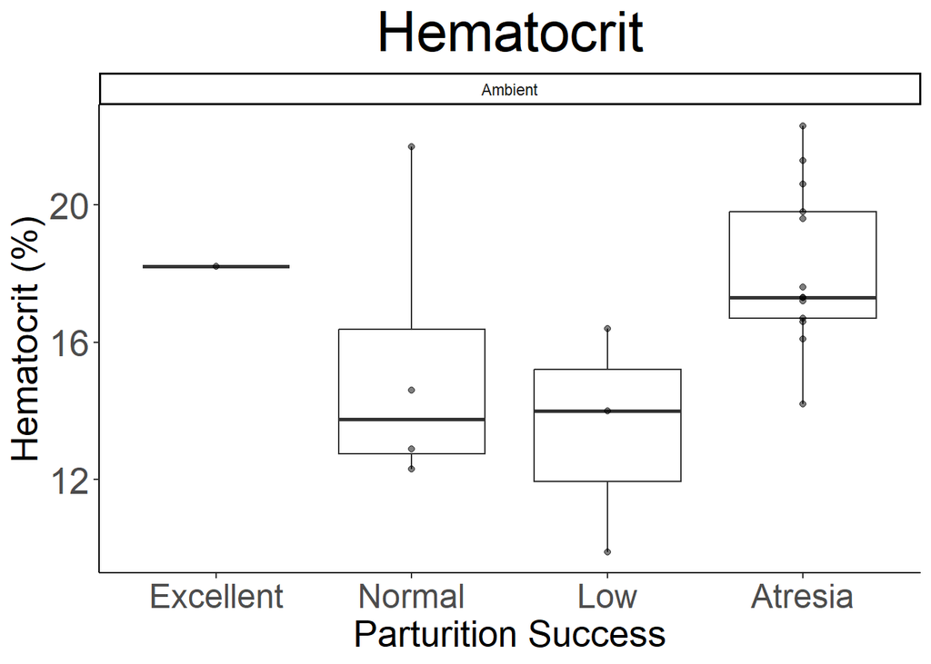

```r
# hct boxplot

# Ambient Samples
hct_ambient_boxplot <- ggplot(data = Ambient_Samples) +
  geom_boxplot(aes(x = Consensus_Brood_Condition, y = Hct....)) +
  geom_point(aes(x = Consensus_Brood_Condition, y = Hct....), alpha = 0.5, colour = "black") +
  labs(title = "Hematocrit", x = "Parturition Success", y = "Hematocrit (%)") +
  facet_wrap(~ Ambient.Or.OAH) +
  theme_classic() +
  theme(panel.background = element_rect(fill = "white"),
        plot.background = element_rect(fill = "white"),
        legend.background = element_rect(fill = "white", color = "black"),
        title = element_text(size = 12),
        plot.title = element_text(size = 30, hjust = 0.5),
        axis.text.x = element_text(size = 18),
        axis.text.y = element_text(size = 20),
        axis.title.x = element_text(size = 20),
        axis.title.y = element_text(size = 20))

print(hct_ambient_boxplot)
```

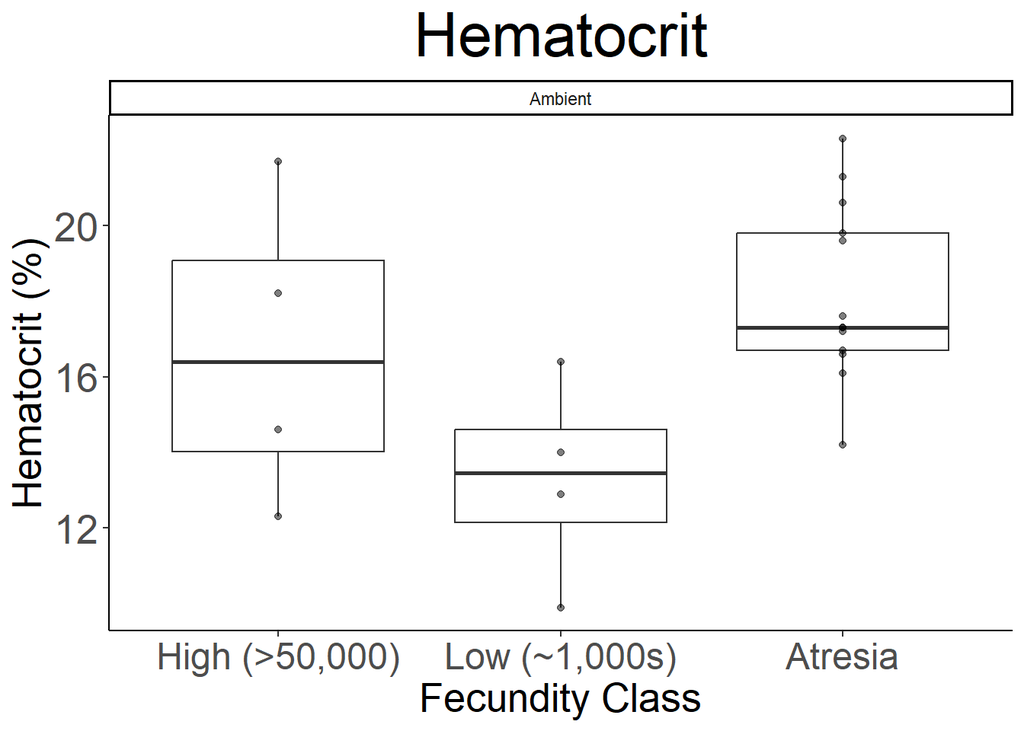

```r
ggsave(filename = "data-images/hct_ambient_boxplot.pdf", plot = hct_ambient_boxplot, device = "pdf")
ggsave(filename = "data-images/hct_ambient_boxplot.png", plot = hct_ambient_boxplot, device = "png")
hct_ambient_fecundity_boxplot <- ggplot(data = Ambient_Samples) +
  geom_boxplot(aes(x = Fecundity_Class, y = Hct....)) +
  geom_point(aes(x = Fecundity_Class, y = Hct....), alpha = 0.5, colour = "black") +
  labs(title = "Hematocrit", x = "Fecundity Class", y = "Hematocrit (%)") +
  facet_wrap(~ Ambient.Or.OAH) +
  theme_classic() +
  theme(panel.background = element_rect(fill = "white"),
        plot.background = element_rect(fill = "white"),
        legend.background = element_rect(fill = "white", color = "black"),
        title = element_text(size = 12),
        plot.title = element_text(size = 30, hjust = 0.5),
        axis.text.x = element_text(size = 18),
        axis.text.y = element_text(size = 20),
        axis.title.x = element_text(size = 20),
        axis.title.y = element_text(size = 20))

print(hct_ambient_fecundity_boxplot)
```

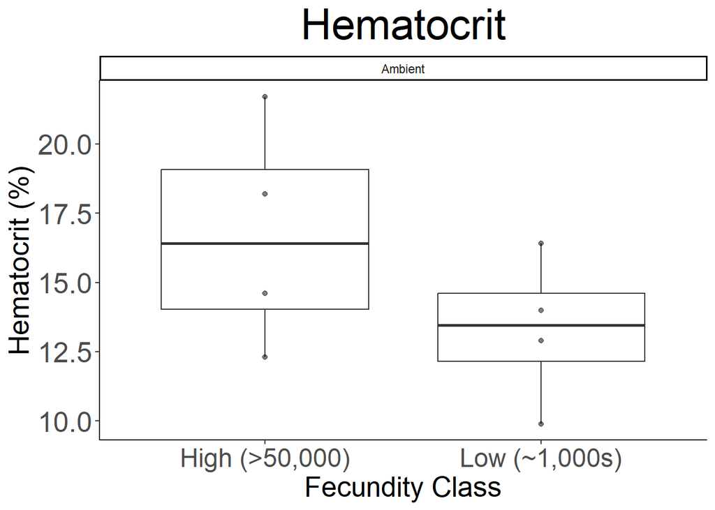

```r
ggsave(filename = "data-images/hct_ambient_fecundity_boxplot.pdf", plot = hct_ambient_fecundity_boxplot, device = "pdf")
ggsave(filename = "data-images/hct_ambient_fecundity_boxplot.png", plot = hct_ambient_fecundity_boxplot, device = "png")
hct_amb_fec_no_atresia_boxplot <- ggplot(data = Amb_Fec_No_Atresia_Samples) +
  geom_boxplot(aes(x = Fecundity_Class, y = Hct....)) +
  geom_point(aes(x = Fecundity_Class, y = Hct....), alpha = 0.5, colour = "black") +
  labs(title = "Hematocrit", x = "Fecundity Class", y = "Hematocrit (%)") +
  facet_wrap(~ Ambient.Or.OAH) +
  theme_classic() +
  theme(panel.background = element_rect(fill = "white"),
        plot.background = element_rect(fill = "white"),
        legend.background = element_rect(fill = "white", color = "black"),
        title = element_text(size = 12),
        plot.title = element_text(size = 30, hjust = 0.5),
        axis.text.x = element_text(size = 18),
        axis.text.y = element_text(size = 20),
        axis.title.x = element_text(size = 20),
        axis.title.y = element_text(size = 20))

print(hct_amb_fec_no_atresia_boxplot)
```

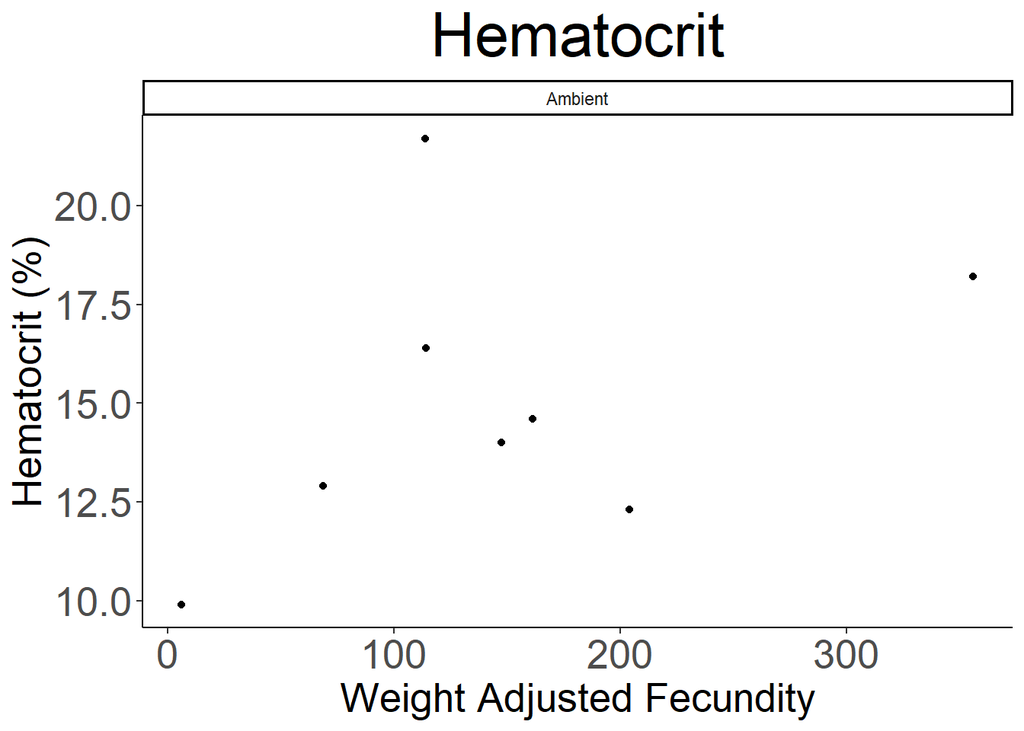

```r
ggsave(filename = "data-images/hct_amb_fec_no_atresia_boxplot.pdf", plot = hct_amb_fec_no_atresia_boxplot, device = "pdf")
ggsave(filename = "data-images/hct_amb_fec_no_atresia_boxplot.png", plot = hct_amb_fec_no_atresia_boxplot, device = "png")
hct_amb_fec_no_atresia_scatterplot <- Amb_Fec_No_Atresia_Samples %>%
  ggplot() +
  geom_point(aes(x = Weight_Adjusted_Fecundity_Fecundity.Mean_Weight, y = Hct....), colour = "black") +
  labs(title = "Hematocrit", x = "Weight Adjusted Fecundity", y = "Hematocrit (%)") +
  facet_wrap(~ Ambient.Or.OAH) +
  theme_classic() +
  theme(panel.background = element_rect(fill = "white"),
        plot.background = element_rect(fill = "white"),
        legend.background = element_rect(fill = "white", color = "black"),
        title = element_text(size = 12),
        plot.title = element_text(size = 30, hjust = 0.5),
        axis.text.x = element_text(size = 20),
        axis.text.y = element_text(size = 20),
        axis.title.x = element_text(size = 20),
        axis.title.y = element_text(size = 20))

print(hct_amb_fec_no_atresia_scatterplot)
```

```r
ggsave(filename = "data-images/hct_amb_fec_no_atresia_scatterplot.pdf", plot = hct_amb_fec_no_atresia_scatterplot, device = "pdf")
ggsave(filename = "data-images/hct_amb_fec_no_atresia_scatterplot.png", plot = hct_amb_fec_no_atresia_scatterplot, device = "png")
```